# UArizona EDSci Fellowship

Summer professional development workshop: Introduction to R using RStudio

Adriana Picoral

June 11, 2021

# Install R and RStudio

We are using RStudio as our IDE for this course. If you are running your R code in your computer, you need to install both R and RStudio. Alternatively, you can create a free account at http://rstudio.cloud and run your R code in the cloud. Either way, we will be using the same IDE (i.e., RStudio).

What’s an **IDE**? IDE stands for **i**ntegrated **d**evelopment **e**nvironment, and its goal is to facilitate coding by integrating a **text editor**, a **console** and other tools into one window.

## I’ve never installed R and RStudio in my computer OR I’m not sure I have R and RStudio installed in my computer

1. Download and install R from https://cran.r-project.org (If you are a Windows user, first [determine if you are running the 32 or the 64 bit version](https://www.computerhope.com/issues/ch001121.htm#:~:text=Press%20and%20hold%20the%20Windows,running%20the%2064%2Dbit%20version.))
2. Download and install RStudio from https://rstudio.com/products/rstudio/download/#download

Here’s a [video on how to install R and RStudio on a mac](https://youtu.be/Iwp8bm7w4fQ).

## I already have R and RStudio installed

1. Open RStudio
2. Check your R version by entering `sessionInfo()` on your console.
3. The latest release for R was on 2021/05/19 (R version 4.1.0 Camp Pontanezen). If your R version is older than the most recent version, please follow step 1 in the previous section to update R.
4. Check your RStudio version, if your version is older than Version 1.4.x, please follow step 2 in the previous section to update RStudio.

How often should I update R and RStudio? Always make sure that you have the latest version of R, RStudio, and the packages you’re using in your code to ensure you are not running into bugs that are caused by having older versions installed in your computer.

When [asked](https://community.rstudio.com/t/should-i-update-all-my-r-packages-frequently-yes-no-why/5856/4), [Jenny Bryan](https://community.rstudio.com/u/jennybryan) summarizes the importance of keeping your system up-to-date saying that “You will always eventually have a reason that you must update. So you can either do that very infrequently, suffer with old versions in the middle, and experience great pain at update. Or admit that maintaining your system is a normal ongoing activity, and do it more often.”

You can ensure your packages are also up-to-date by clicking on “Tools” on your RStudio top menu bar, and selecting “Check for Packages Updates…”

# Why learn R?

R is both a programming language and [a free software environment for statistical computing and graphics](https://www.r-project.org/). In addition to being free, here are other reasons to learn R:

- **R is popular.** According to [Robert A. Muenchen’s post on the popularity of data science software](http://r4stats.com/articles/popularity/) (which is updated frequently), R is among the top 5 technologies that are mentioned in data science job ads on indeed.com.
- **R is very powerful and versatile**. From creating websites (like this bookdown you’re reading right now) to building machine learning models, R has it all.
- **The R community is active and very supportive**. Because R is so popular, there are a number of forums on R. A good way to get a glimpse on how active the R community is to follow [`#rstats`](https://twitter.com/search?q=%23rstats) on twitter.

# Why use RStudio?

You can just use R, but RStudio is an IDE that makes using R easier and more fun. Some features that make RStudio the IDE that many data scientists use:

- RStudio is **free** and **open source**.
- RStudio contains a full-feature integrated text editor, with tab-completion, spellcheck, etc.
- RStudio is a cross-platform interface that looks the same across platforms.
- RStudio allows you to organize your data science projects so you’re not always hunting for the right script that goes with the data you want to analyze. (also, it integrates nicely with `rmarkdown` and `knitr`)

## Create an R Project

In today’s class, we will focus on situating ourselves around our IDE. For every lesson, we will either start a new R project or open an R project we’ve been working on.

Why create a RStudio project? RStudio projects make it easier to keep your projects organized, since each project has their own working directory, workspace, history, and source documents. In other words, it’s much easier to open an R project and not have to worry about setting your working directory than to try to hunt down your files.

Here are the steps we are starting with today:

1. Start a new R project
2. Create a new R script
3. Save that R script as 01-covid-vaccines-exploration

**STOP AND THINK**

Take a moment to look around your IDE. What are the main panes on the RStudio interface. What are the 4 main areas of the interface? Can you guess what each area is for?

# Data Analysis

In this part of the exam, you will be working with [Google’s mobility report](https://www.google.com/covid19/mobility/), which displays changes to visits to different places like retail and recreation, grocery and pharmacy, transit stations, etc. We will look into the data in more detail, but first we need to install a couple of packages.

## Install and load libraries

```r
library(ggthemes)
library(tidyverse)
```

## Read data in

Google has created [a checklist](https://support.google.com/covid19-mobility/checklist/9834261), to help us contextualize our data analysis. We will be working with data for Arizona only.

Use the function `read_csv()` to read comma separated values files in.

```r
arizona_mobility_report <- read_csv("data/arizona_mobility_report.csv")
```

You can use `glimpse()` to get a glipmse of the data or `summary()` to get a summary of each variable.

```r
glimpse(arizona_mobility_report)
```

```
## Rows: 35,514
## Columns: 7
## $ sub_region                   <chr> "Apache County", "Apache County", "Apache…
## $ census_fips_code             <chr> "04001", "04001", "04001", "04001", "0400…
## $ place_id                     <chr> "ChIJ-WDLw6lhJYcRcrSQ4ttk6sE", "ChIJ-WDLw…
## $ date                         <date> 2020-02-15, 2020-02-15, 2020-02-15, 2020…
## $ user_id                      <chr> "001", "001", "001", "001", "001", "002",…
## $ place                        <chr> "retail and recreation", "grocery and pha…
## $ percent_change_from_baseline <dbl> 16, 3, 26, 96, -2, 17, 5, 42, 18, -7, -2,…
```

```r
summary(arizona_mobility_report)
```

```
##   sub_region        census_fips_code     place_id              date
##  Length:35514       Length:35514       Length:35514       Min.   :2020-02-15
##  Class :character   Class :character   Class :character   1st Qu.:2020-06-05
##  Mode  :character   Mode  :character   Mode  :character   Median :2020-10-04
##                                                           Mean   :2020-09-29
##                                                           3rd Qu.:2021-01-23
##                                                           Max.   :2021-05-13
##    user_id             place           percent_change_from_baseline
##  Length:35514       Length:35514       Min.   :-88.000
##  Class :character   Class :character   1st Qu.:-25.000
##  Mode  :character   Mode  :character   Median : -9.000
##                                        Mean   : -7.859
##                                        3rd Qu.:  7.000
##                                        Max.   :306.000
```

## Explore Data

```r
arizona_mobility_report %>%
  count(place)
```

```
## # A tibble: 6 x 2
##   place                     n
##   <chr>                 <int>
## 1 grocery and pharmacy   6022
## 2 parks                  5663
## 3 residential            5725
## 4 retail and recreation  6225
## 5 transit stations       5297
## 6 workplaces             6582
```

## Visualize data

### Visualizing raw data

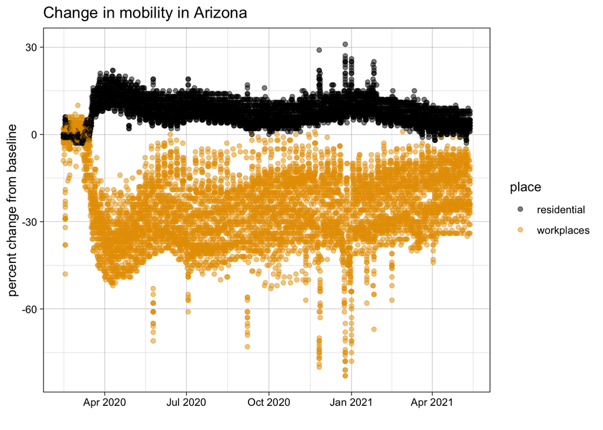

```r
arizona_mobility_report %>%
  filter(place %in% c("residential", "workplaces")) %>%
  ggplot(aes(x = date,
             y = percent_change_from_baseline,
             color = place)) +
  geom_point(alpha = .5) +
  theme_linedraw() +
  labs(x = "",
       y = "percent change from baseline",
       title = "Change in mobility in Arizona") +
  scale_color_colorblind()
```

### Visualizing summarized data

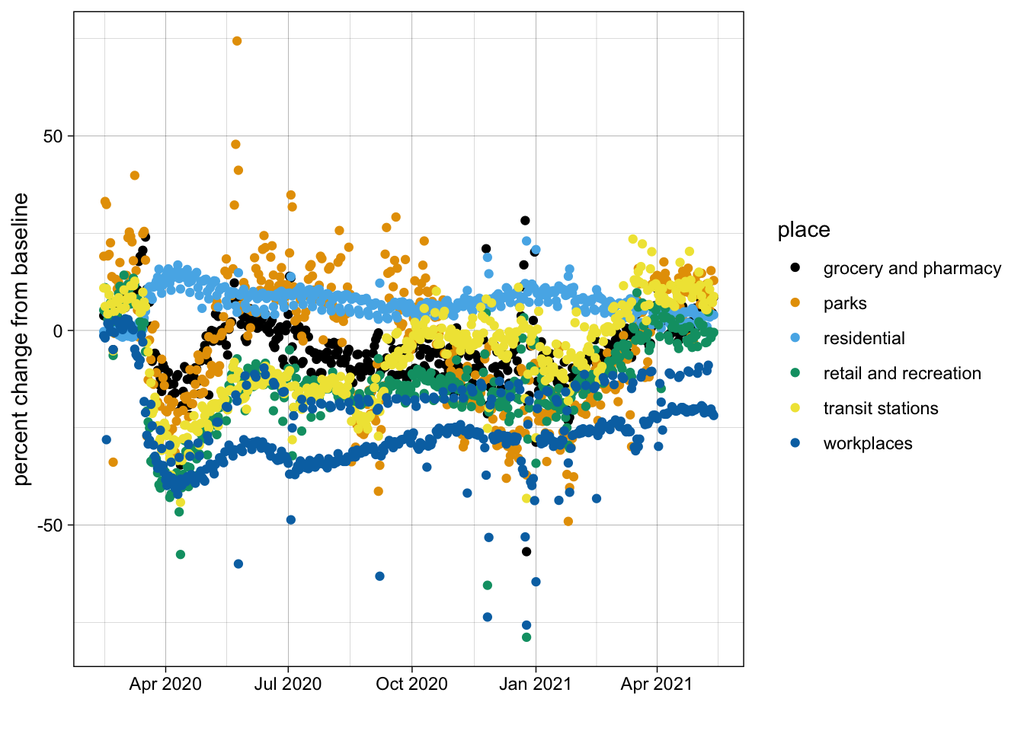

```r
arizona_mobility_report %>%
  group_by(place, date) %>%
  summarize(mean_percent_change = mean(percent_change_from_baseline)) %>%
  ggplot(aes(x = date,
             y = mean_percent_change,
             color = place)) +
  geom_point() +
  theme_linedraw() +
  labs(x = "",
       y = "percent change from baseline") +
  scale_color_colorblind()
```

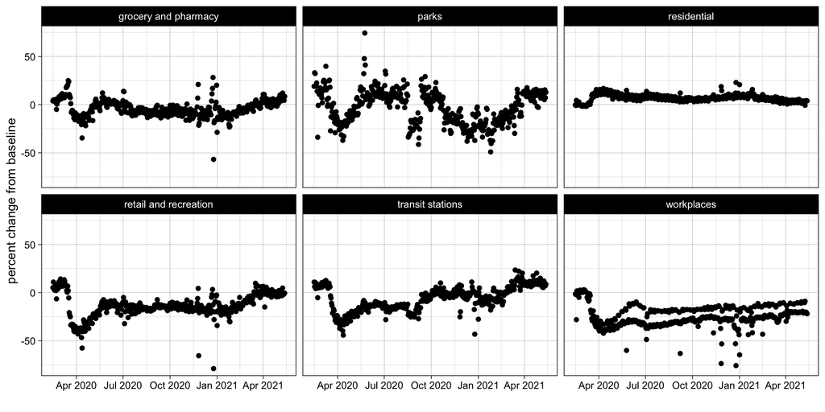

```r
arizona_mobility_report %>%
  group_by(place, date) %>%
  summarize(mean_percent_change = mean(percent_change_from_baseline)) %>%
  ggplot(aes(x = date,
             y = mean_percent_change)) +
  geom_point() +
  theme_linedraw() +
  labs(x = "",
       y = "percent change from baseline") +
  facet_wrap(~place)
```

### Modeling data and visualizing results

```r
mobility_model <- arizona_mobility_report %>%
  lm(formula = percent_change_from_baseline ~ place + sub_region)

summary(mobility_model)
```

```
##
## Call:
## lm(formula = percent_change_from_baseline ~ place + sub_region,
##     data = .)
##
## Residuals:
##     Min      1Q  Median      3Q     Max
## -85.202 -11.271  -0.630   9.529 288.647
##
## Coefficients:
##                              Estimate Std. Error t value Pr(>|t|)
## (Intercept)                  -2.71249    0.46665  -5.813 6.20e-09 ***
## placeparks                    1.88185    0.37513   5.016 5.29e-07 ***
## placeresidential             10.84500    0.37274  29.095  < 2e-16 ***
## placeretail and recreation   -9.26922    0.36477 -25.411  < 2e-16 ***
## placetransit stations        -0.01613    0.38336  -0.042 0.966445
## placeworkplaces             -20.94402    0.36206 -57.847  < 2e-16 ***
## sub_regionCochise County     -5.61445    0.55998 -10.026  < 2e-16 ***
## sub_regionCoconino County    10.73188    0.56019  19.158  < 2e-16 ***
## sub_regionGila County        15.41817    0.59666  25.841  < 2e-16 ***
## sub_regionGraham County       3.44100    0.65876   5.223 1.77e-07 ***
## sub_regionGreenlee County    -4.04965    1.12435  -3.602 0.000316 ***
## sub_regionLa Paz County     -20.18292    0.58692 -34.388  < 2e-16 ***
## sub_regionMaricopa County   -11.13108    0.55748 -19.967  < 2e-16 ***
## sub_regionMohave County       5.57432    0.55757   9.997  < 2e-16 ***
## sub_regionNavajo County      18.18343    0.56257  32.322  < 2e-16 ***
## sub_regionPima County       -11.46184    0.55748 -20.560  < 2e-16 ***
## sub_regionPinal County       -7.65714    0.55748 -13.735  < 2e-16 ***
## sub_regionSanta Cruz County -10.65113    0.56985 -18.691  < 2e-16 ***
## sub_regionYavapai County      7.51677    0.55968  13.431  < 2e-16 ***
## sub_regionYuma County       -14.44565    0.55872 -25.855  < 2e-16 ***
## ---
## Signif. codes:  0 '***' 0.001 '**' 0.01 '*' 0.05 '.' 0.1 ' ' 1
##
## Residual standard error: 20.17 on 35494 degrees of freedom
## Multiple R-squared:  0.3643, Adjusted R-squared:  0.364
## F-statistic:  1071 on 19 and 35494 DF,  p-value: < 2.2e-16
```

```r
library(effects)
```

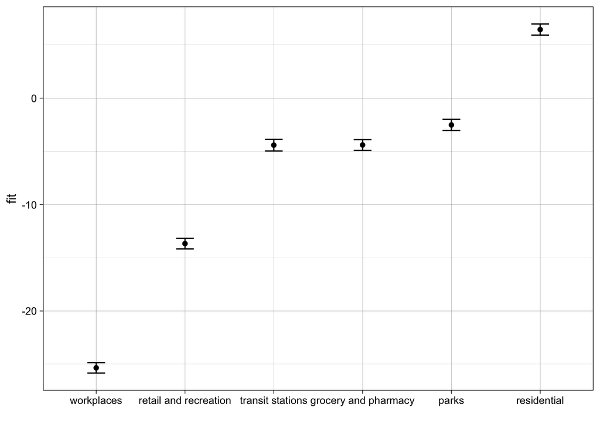

```r
effect("place", mobility_model) %>%
  data.frame() %>%
  ggplot(aes(x = reorder(place, fit),
             y = fit,
             ymin = lower,
             ymax = upper)) +
  geom_errorbar(width = .2) +
  geom_point() +
  labs(x = "") +
  theme_linedraw()
```

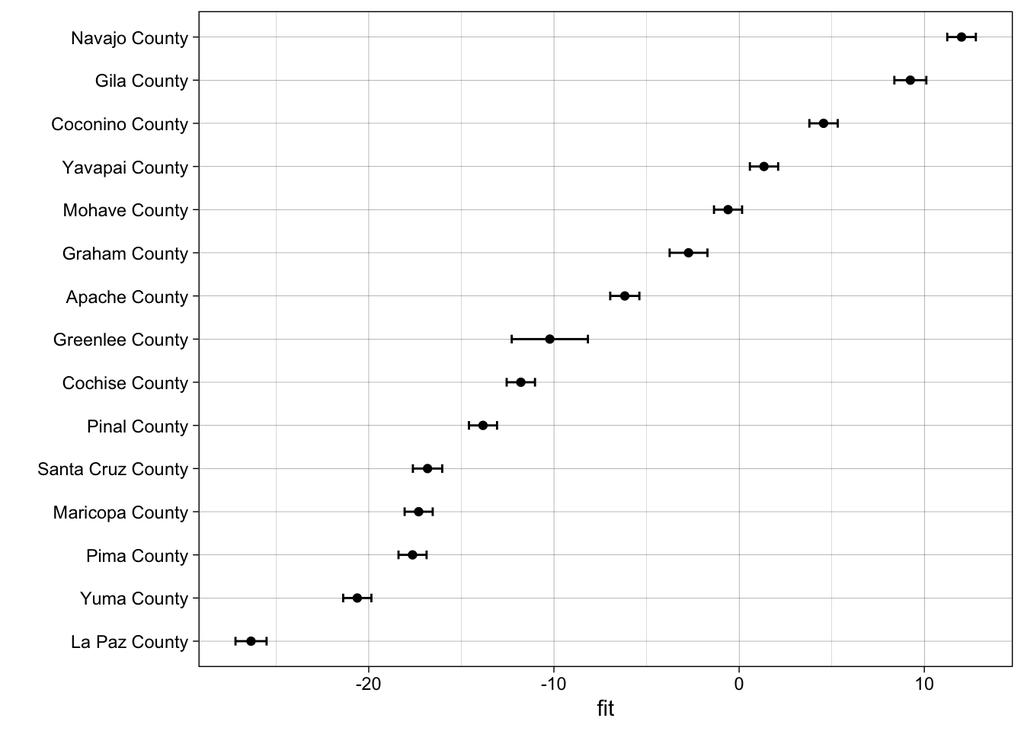

```r
effect("sub_region", mobility_model) %>%
  data.frame() %>%
  ggplot(aes(y = reorder(sub_region, fit),
             x = fit,
             xmin = lower,
             xmax = upper)) +
  geom_errorbar(width = .2) +
  geom_point() +
  labs(y = "") +
  theme_linedraw()
```

#### Interaction

```r
mobility_model_int <- arizona_mobility_report %>%
  lm(formula = percent_change_from_baseline ~ place + sub_region + place:sub_region)

summary(mobility_model_int)
```

```
##
## Call:
## lm(formula = percent_change_from_baseline ~ place + sub_region +
##     place:sub_region, data = .)
##
## Residuals:
##     Min      1Q  Median      3Q     Max
## -97.890  -7.203  -0.474   6.607 253.693
##
## Coefficients: (5 not defined because of singularities)
##                                                        Estimate Std. Error
## (Intercept)                                             -0.8454     0.8286
## placeparks                                              11.2785     1.1832
## placeresidential                                         9.7736     1.1993
## placeretail and recreation                             -11.8716     1.1788
## placetransit stations                                   -9.9238     1.1705
## placeworkplaces                                        -27.2327     1.1580
## sub_regionCochise County                                -7.7383     1.1543
## sub_regionCoconino County                                7.1965     1.1568
## sub_regionGila County                                   22.3057     1.1711
## sub_regionGraham County                                  0.3255     1.2101
## sub_regionGreenlee County                                0.9631     2.5367
## sub_regionLa Paz County                                -28.5157     1.2615
## sub_regionMaricopa County                               -8.7427     1.1543
## sub_regionMohave County                                  4.2794     1.1543
## sub_regionNavajo County                                 11.8037     1.1691
## sub_regionPima County                                   -9.9519     1.1543
## sub_regionPinal County                                  -6.1524     1.1543
## sub_regionSanta Cruz County                            -25.2810     1.2289
## sub_regionYavapai County                                 4.5657     1.1543
## sub_regionYuma County                                  -15.7339     1.1543
## placeparks:sub_regionCochise County                    -20.9536     1.6520
## placeresidential:sub_regionCochise County                5.3101     1.6522
## placeretail and recreation:sub_regionCochise County      3.0478     1.6374
## placetransit stations:sub_regionCochise County          13.7802     1.6429
## placeworkplaces:sub_regionCochise County                10.3781     1.6225
## placeparks:sub_regionCoconino County                    27.2608     1.6537
## placeresidential:sub_regionCoconino County              -6.7195     1.6540
## placeretail and recreation:sub_regionCoconino County     1.0976     1.6392
## placetransit stations:sub_regionCoconino County          5.5004     1.6446
```

[output cut: 143 more lines]

```
## placeresidential:sub_regionYavapai County               -4.740 2.15e-06 ***
## placeretail and recreation:sub_regionYavapai County      0.269 0.788209
## placetransit stations:sub_regionYavapai County          14.133  < 2e-16 ***
## placeworkplaces:sub_regionYavapai County                 1.137 0.255482
## placeparks:sub_regionYuma County                       -16.855  < 2e-16 ***
## placeresidential:sub_regionYuma County                   8.434  < 2e-16 ***
## placeretail and recreation:sub_regionYuma County         1.825 0.068006 .
## placetransit stations:sub_regionYuma County              1.912 0.055838 .
## placeworkplaces:sub_regionYuma County                    8.516  < 2e-16 ***
## ---
## Signif. codes:  0 '***' 0.001 '**' 0.01 '*' 0.05 '.' 0.1 ' ' 1
##
## Residual standard error: 17.12 on 35429 degrees of freedom
## Multiple R-squared:  0.5429, Adjusted R-squared:  0.5418
## F-statistic:   501 on 84 and 35429 DF,  p-value: < 2.2e-16
```

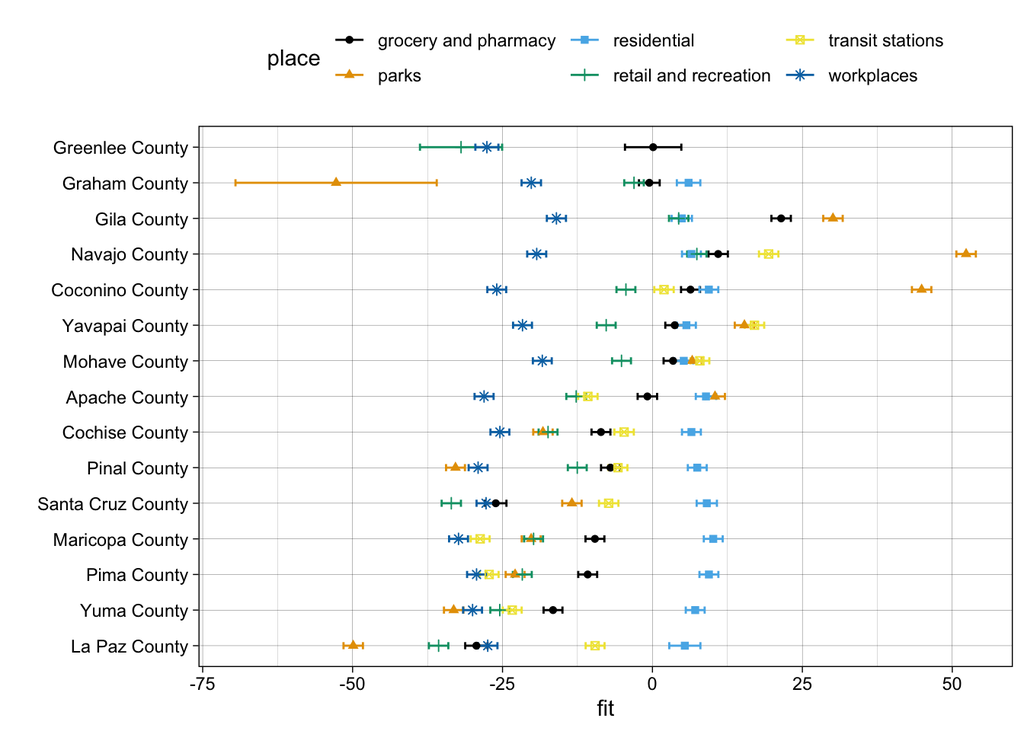

```r
effect("place:sub_region", mobility_model_int) %>%
  data.frame() %>%
  ggplot(aes(y = reorder(sub_region, fit),
             x = fit,
             xmin = lower,
             xmax = upper,
             color = place,
             shape = place)) +
  geom_errorbar(width = .2) +
  geom_point() +
  labs(y = "") +
  theme_linedraw() +
  theme(legend.position = "top") +
  scale_color_colorblind()
```

# Sample acvitivity

For the sample activity you can follow the written tutorial and [watch the demonstration video](https://youtu.be/XZHnwVs5MtA) of the same learning activity.

# Extra resources

- [R for Data Science](https://r4ds.had.co.nz/) by Hadley Wickham and Garret Grolemund
- [RStudio Education](https://education.rstudio.com/), with resources for learners and teachers